# Linear Models Project — M1 (2025–2026)

## 6.4 Scenario- Based Interpretation

To make the **results more concrete, we use the final model to predict exam scores for two realistic student profiles** that represent very different academic situations.

```r
# Profile 1: "High-performing" student
profile_high <- data.frame(
  attend_pct = 95,
  study_hrs = 25,
  age = 16,
  sleep_hrs = 8,
  parent_educ = "PHD",
  sleep_qual = "Good",
  trav_time = "<15 Min",
  school_type = "Private",
  web_access = "Yes"
)

# Prediction with confidence interval
pred_high <- predict(final_model, newdata = profile_high, interval = "confidence")
pred_high
```

```
##        fit      lwr      upr
## 1 110.4225 108.6498 112.1952
```

```r
# Profile 2: "At-risk" student
profile_risk <- data.frame(
  attend_pct = 55,
  study_hrs = 3,
  age = 17,
  sleep_hrs = 5,
  parent_educ = "No Formal",
  sleep_qual = "Poor",
  trav_time = ">60 Min",
  school_type = "Public",
  web_access = "No"
)


# Prediction with confidence interval
pred_risk <- predict(final_model, newdata = profile_risk, interval = "confidence")
pred_risk
```

```
##        fit      lwr      upr
## 1 23.78561 22.92822 24.64301
```

### 6.4.1 Comparison

```r
# Predicted difference between profiles
diff_score <- pred_high[1] - pred_risk[1]
diff_score
```

```
## [1] 86.63688
```

```
## The high-performing student is predicted to score 110.42 points (95% CI: 108.65 , 112.2 ).
##
##  The at-risk student is predicted to score 23.79 points (95% CI: 22.93 , 24.64 ).
##
##  The predicted difference between the two profiles is approximately 86.64 points, illustrating the cumulative effect of multiple favorable versus unfavorable factors.
```

At this stage, one suggests doing an improvement scenario : what if the at-risk student improved attendance from 55% to 80%?

```r
profile_improved <- profile_risk
profile_improved$attend_pct <- 80

pred_improved <- predict(final_model, newdata = profile_improved, interval = "confidence")
pred_improved
```

```
##        fit      lwr      upr
## 1 35.45835 34.29213 36.62457
```

```r
improvement <- pred_improved[1] - pred_risk[1]
improvement
```

```
## [1] 11.67274
```

```
## Improving attendance by 25 percentage points (from 55% to 80%) is associated with an increase of approximately 11.67 points in the predicted exam score.
```

## 6.5 Practical vs statistical significance

```r
# Extract p-values and effect sizes
coef_summary <- summary(final_model)$coefficients

# Identify statistically significant predictors (p < 0.05)
sig_predictors <- rownames(coef_summary)[coef_summary[, 4] < 0.05]
sig_predictors
```

```
##  [1] "(Intercept)"                "attend_pct"
##  [3] "study_hrs"                  "sleep_hrs"
##  [5] "parent_educHigh School"     "parent_educGraduate"
##  [7] "parent_educPost Graduate 1" "parent_educPost Graduate 2"
##  [9] "parent_educPHD"             "sleep_qualAverage"
## [11] "sleep_qualGood"             "trav_time30-60 Min"
## [13] "trav_time>60 Min"           "school_typePrivate"
## [15] "web_accessYes"
```

Recall that a variable can be **statistically significant** without being really important in practice. A low p-value indicates that an estimated effect is unlikely to be zero, but it does not provide information about **the magnitude of the effect or its practical relevance**.

This is clearly the case for **attendance rate**. Attendance is highly statistically significant, but more importantly, its effect is large. A **10 percentage point increase in attendance** leads to several additional points on the exam score. In practice, this can make a real difference, for example moving a student from an average result to a much better one.

Therefore, for this reason, we focus our interpretation on variables that are **both statistically significant and practically meaningful**, such as attendance rate, study hours, parental education, sleep quality and travel time. These factors have effects that are large enough to matter for students’ academic performance.

## 6.6 Model Fit Summary

```r
# Model fit statistics
r2 <- summary(final_model)$r.squared
adj_r2 <- summary(final_model)$adj.r.squared
sigma <- summary(final_model)$sigma
n_obs <- nrow(data_clean)
n_pred <- length(coef(final_model)) - 1
```

**Interpretation:**

The final model explains around **71%** of the variation in exam scores, as indicated by the **R²**. After adjusting for the number of predictors, the **adjusted R² remains very close**, showing that the explanatory power of the model is not driven by overfitting. The **residual standard error is about 8.2** points, which means that individual predictions can differ from actual scores by several points. This level of uncertainty is expected in educational data, but finally the model captures the main systematic patterns in exam performance. In addition, the **global F-test** is statistically significant **(F-test p < 0.001)**, meaning that the predictors jointly explain a significant portion of variance.

# 7 Predictive Performance

In this section, we evaluate the **predictive performance** of the selected models. To this end, the data are split into a training set and a test set. Models are fitted on the training data and their out-of-sample performance is assessed on the test data.

## 7.1 Train/Test Split

```r
set.seed(42)

n <- nrow(data_clean)
idx_train <- sample(seq_len(n), size = 0.8 * n)

train <- data_clean[idx_train, ]
test  <- data_clean[-idx_train, ]

cat("Training set size:", nrow(train), "\n")
```

```
## Training set size: 4000
```

```r
cat("Test set size:", nrow(test), "\n")
```

```
## Test set size: 1000
```

We use a **train/test split** approach with the following protocol:  
- **Split ratio:** 80% training / 20% test  
- **Random seed:** `set.seed(42)` for reproducibility  
- **Training set:** Used to fit the models  
- **Test set:** Held out to evaluate out-of-sample performance (simulates “new students”)

**Why train/test split?**  
- It provides an unbiased estimate of model performance on unseen data.  
- It helps detect overfitting (if test performance is much worse than training performance).  
- The 80/20 ratio is a standard choice that balances having enough data for training while retaining sufficient test data for reliable.

## 7.2 Training and Test-Based Prediction

```r
# Refit all candidate models on training data only
mod0_tr <- lm(y ~ attend_pct + study_hrs + age + sleep_hrs, data = train)

mod1_tr <- lm(y ~ attend_pct + study_hrs + age + sleep_hrs +
                parent_educ + sleep_qual + trav_time +
                school_type + web_access, data = train)

mod2_tr <- lm(y ~ attend_pct + study_hrs + age + sleep_hrs +
                parent_educ + sleep_qual + trav_time +
                school_type + web_access +
                extra_act + study_method, data = train)
```

- To ensure a fair evaluation of predictive performance, we **refit all candidate models using only the training data**. This is a critical step to avoid **data leakage**: if we used the full-sample models (mod0, mod1, mod2) for prediction, the test observations would have influenced the coefficient estimates, leading to overly optimistic performance metrics.

```r
pred0 <- predict(mod0_tr, newdata = test)
pred1 <- predict(mod1_tr, newdata = test)  # final model
pred2 <- predict(mod2_tr, newdata = test)

# Baseline: predict training mean
y_mean <- mean(train$y)
pred_base <- rep(y_mean, nrow(test))
```

We now generate predictions for the held-out test observations using each training-fitted model. Additionally, we include a **naive baseline predictor** that simply predicts the training-set mean for all observations. This baseline serves as a reference point: any useful model should outperform this trivial prediction.

- `pred0`,`pred1`,`pred2`: Predictions from the three regression models
- `pred_base`: Naive baseline (training mean applied to all test cases)

## 7.3 Performance Metrics

We evaluate predictive performance on the test set using metrics suited for out-of-sample evaluation:

- **MSE**: Primary metric (used by the instructor for ranking)
- **RMSE**: Square root of MSE, reported for interpretability on the original scale of the response
- **R²_test**: Out-of-sample variance explained
- **MedAE**: Robust measure of typical prediction error

Note: These metrics differ from in-sample criteria (AIC, BIC) used for model selection in Part 3, which penalize model complexity. Here, we directly assess prediction accuracy on unseen data.

```r
# Define metric functions
mse <- function(y, yhat) mean((y - yhat)^2)
rmse <- function(y, yhat) sqrt(mean((y - yhat)^2))
r2_oos <- function(y, yhat) 1 - sum((y - yhat)^2) / sum((y - mean(y))^2)
medae <- function(y, yhat) median(abs(y - yhat))
```

```r
# Performance comparison table
perf <- tibble(
  Model = c("Baseline", "mod0", "mod1 (final)", "mod2"),
  MSE = c(mse(test$y, pred_base), mse(test$y, pred0),
          mse(test$y, pred1), mse(test$y, pred2)),
  RMSE = c(rmse(test$y, pred_base), rmse(test$y, pred0),
           rmse(test$y, pred1), rmse(test$y, pred2)),
  R2_test = c(r2_oos(test$y, pred_base), r2_oos(test$y, pred0),
              r2_oos(test$y, pred1), r2_oos(test$y, pred2)),
  MedAE = c(medae(test$y, pred_base), medae(test$y, pred0),
            medae(test$y, pred1), medae(test$y, pred2))
)

perf
```

| Model | MSE | RMSE | R2_test | MedAE |
| --- | --- | --- | --- | --- |
| Baseline | 224.40911 | 14.980291 | -0.0001427998 | 10.052500 |
| mod0 | 71.60791 | 8.462146 | 0.6808590549 | 5.458827 |
| mod1 (final) | 64.48353 | 8.030164 | 0.7126108831 | 5.430834 |
| mod2 | 63.34791 | 7.959140 | 0.7176720890 | 5.474555 |

## 7.4 Improvement Over Baseline

```r
baseline_mse <- perf$MSE[perf$Model == "Baseline"]
baseline_rmse <- perf$RMSE[perf$Model == "Baseline"]

perf_improve <- perf %>%
  mutate(
    MSE_reduction_pct = round(100 * (baseline_mse - MSE) / baseline_mse, 1),
    RMSE_reduction_pct = round(100 * (baseline_rmse - RMSE) / baseline_rmse, 1)
  )

perf_improve %>%
  select(Model, MSE, RMSE, R2_test, MSE_reduction_pct)
```

| Model | MSE | RMSE | R2_test | MSE_reduction_pct |
| --- | --- | --- | --- | --- |
| Baseline | 224.40911 | 14.980291 | -0.0001427998 | 0.0 |
| mod0 | 71.60791 | 8.462146 | 0.6808590549 | 68.1 |
| mod1 (final) | 64.48353 | 8.030164 | 0.7126108831 | 71.3 |
| mod2 | 63.34791 | 7.959140 | 0.7176720890 | 71.8 |

**Key findings:**

- All regression models substantially improve over baseline
- **mod1 (final)** achieves nearly identical performance to mod2
- This confirms that `extra_act` and `study_method` add little predictive value
- **The simpler model is preferred**

## 7.5 Calibration Plot

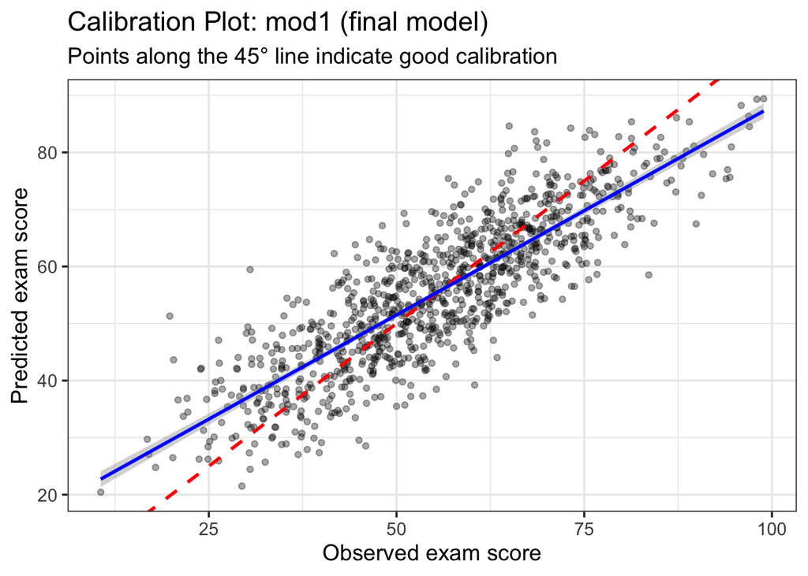

Calibration Plot: Predicted vs Observed

```r
calib_df <- tibble(
  observed  = test$y,
  predicted = pred1
)

ggplot(calib_df, aes(x = observed, y = predicted)) +
  geom_point(alpha = 0.35) +
  geom_abline(slope = 1, intercept = 0, linetype = "dashed", color = "red", linewidth = 1) +
  geom_smooth(method = "lm", se = TRUE, color = "blue") +
  labs(x = "Observed exam score", y = "Predicted exam score",
       title = "Calibration Plot: mod1 (final model)",
       subtitle = "Points along the 45° line indicate good calibration") +
  theme_bw(base_size = 14)
```

## 7.6 Predictive Performance Summary

**Validation protocol:** 80/20 train-test split with `set.seed(42)`

| Metric | mod1 (final) | Interpretation |
| --- | --- | --- |
| Test R² | 0.713 | Close to training R² → no overfitting |
| RMSE | 8.03 | Average prediction error (in exam points) |
| MedAE | 5.43 | 50% of predictions within ±5.4 points |
| MSE reduction vs baseline | 71.3% | Substantial improvement |

**Key findings:**

1. **No overfitting:** Test R² (0.713) is very close to training R² (~0.705), indicating that the model generalizes well to unseen data.
2. **Substantial improvement over baseline:** The final model reduces MSE by 71.3% compared to the naive baseline (predicting the training mean).
3. **Model comparison confirmed:** mod1 and mod2 achieve nearly identical test performance (MSE: 64.5 vs 63.3), confirming that `extra_act` and `study_method` add minimal predictive value. The simpler model is preferred.
4. **Practical accuracy:** With RMSE ≈ 8 points and MedAE ≈ 5.4 points, the model provides reasonably accurate predictions for exam scores on a 0-100 scale.

**CONCLUSION:** The final model (mod1) generalizes well to unseen data, with **no evidence of overfitting**. It substantially outperforms the naive baseline and achieves comparable performance to more complex specifications, supporting its selection on grounds of parsimony.

# 8 Conclusion:

This project combined exploratory data analysis, linear modeling, and validation to study and predict students’ exam performance. While richer specifications slightly improved in-sample fit, model comparison showed that a more **parsimonious** model performed just as well in prediction. For this reason, the final model was chosen as a good compromise between **explanatory power, predictive accuracy, and interpretability**. Finally, the results highlight the central role of attendance, study habits, and socioeconomic factors, and show that simple models can be both informative and effective when they are carefully selected.

# 9 Use of AI

**Purpose:** We used AI for coding assistance (debugging R code, structuring RMarkdown), improving wording of  
interpretations, and suggesting visualization parameters.

**Parts affected:** in parts 3 and 5 of the report, it helped us choose the right parameters and graph types to obtain clear visualizations tailored to the data. Second, in part 4, AI helped us confirm that the chosen regression model was consistent with the analysis results, allowing us to validate our choice.

**Verification:** All code was tested, outputs were checked against expected results, and statistical interpretations  
were validated.